# Introducción a R y RStudio

Ayudantía 01 · FAGOB 2026

Cristóbal Mejías · Facultad de Gobierno

Métodos Cuantitativos para la Administración Pública

marzo de 2026

## ¿Qué veremos hoy?

1. Diagnóstico inicial
2. El ecosistema de software
3. ¿Qué es R y por qué usarlo?
4. Conociendo RStudio
5. Sistema de carpetas
6. Cargar y explorar CASEN 2024

Al final de la sesión vas a poder abrir una base de datos real y explorarla en R.

# Diagnóstico inicial

## ¿Dónde estamos parados?

- ¿Ya tienen R y RStudio instalados?
- ¿Han usado antes algún software estadístico? (SPSS, Stata, Excel…)
- ¿Tienen computador para traer a las próximas ayudantías?

# El ecosistema de software

## ¿Qué herramienta uso para qué?

| Herramienta | ¿Qué es? | ¿Para qué se usa? |
| --- | --- | --- |
| **R** | Lenguaje estadístico | Análisis de datos, modelos, visualizaciones |
| **RStudio / Positron** | Entorno de trabajo (IDE) | Interfaz para escribir código en R |
| **Python** | Lenguaje de programación general | *Machine learning*, automatización, web |
| **VS Code** | Editor de código universal | Programar en cualquier lenguaje |

En este curso usamos R + RStudio: es el estándar en ciencias sociales cuantitativas, es gratuito y produce análisis reproducibles.

# ¿Qué es R y por qué usarlo?

## ¿Qué es R?

R es un **lenguaje de programación estadístico** de código abierto, creado en 1993 por Ross Ihaka y Robert Gentleman (Universidad de Auckland).

- +20.000 paquetes en CRAN
- Comunidad científica global
- Completamente gratuito
- Análisis **reproducibles**

**¿Qué significa reproducible?**

Que otra persona puede tomar tu código y llegar exactamente al mismo resultado.

R lo usan el INE, el Banco Mundial y el Ministerio de Desarrollo Social, entre muchas otras instituciones públicas.

## R vs. otros softwares

|  | R | SPSS | Excel |
| --- | --- | --- | --- |
| Gratuito | ✅ | ❌ | ❌ |
| Reproducible | ✅ | ⚠️ | ❌ |
| Código abierto | ✅ | ❌ | ❌ |
| Gráficos avanzados | ✅ | ⚠️ | ⚠️ |

En administración pública, la **transparencia y reproducibilidad** de los análisis es cada vez más exigida.

# Trabajar ordenadamente

## Proyectos de R (`.Rproj`)

Vamos a trabajar dentro de **proyectos**: el proyecto es nuestro “hogar”. El primer paso es construirlo.

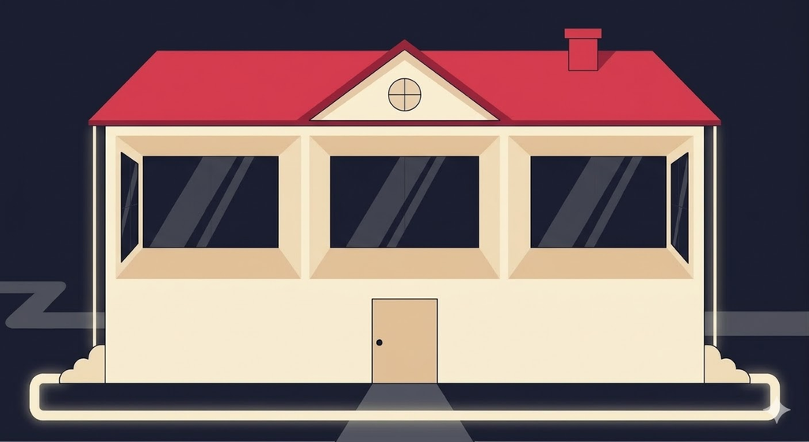

## Crear un proyecto

[figure not shown]

1. *File → New Project → New Directory → New Project*
2. *Directory name*: un nombre sin espacios, por ej. `ayudantia-1`
3. *Browse*: dónde guardarlo, por ej. “Métodos cuantitativos”
4. *Create Project*
5. ¡Tienen su primer proyecto en R!

## Un proyecto sin orden

[figure not shown]

## Explorando RStudio por primera vez

[figure not shown]

Al abrirlo verán **tres paneles**.

## Abrir un script

[figure not shown]

*File → New File → R Script*, o `Ctrl + Shift + N`.

## Los 4 paneles de RStudio

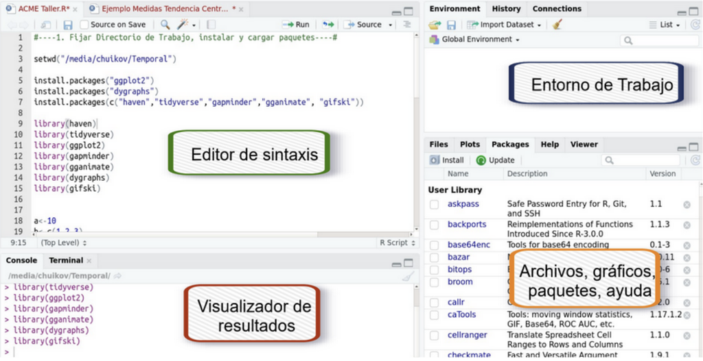

| Panel | Ubicación | ¿Para qué sirve? |
| --- | --- | --- |
| **Script** | Arriba izquierda | Escribir y guardar tu código |
| **Consola** | Abajo izquierda | Ejecutar código y ver resultados |
| **Entorno** | Arriba derecha | Ver objetos y datos cargados |
| **Archivos / Gráficos** | Abajo derecha | Explorar carpetas y ver gráficos |

# Sistema de carpetas

## Cómo organizar tu trabajo: sistema IPO

**I**nput, **P**rocesamiento, **O**utput:

```
ayudantia-1/
├── ayudantia-1.Rproj
├── input/          datos originales
├── procesamiento/  scripts
└── output/         resultados
```

- Siempre sabes dónde está cada cosa
- Evita rutas de archivo rotas
- Facilita el trabajo colaborativo

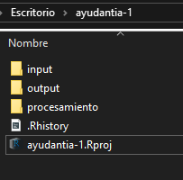

## Así se ve ordenado

[figure not shown]

## Primer contacto con R

Escribe en tu script y ejecuta con `Ctrl + Enter` (el cursor puede estar en cualquier parte de la línea):

```r
# R como calculadora
2 + 2
```

```
[1] 4
```

```r
sqrt(144)
```

```
[1] 12
```

```r
log(100)
```

```
[1] 4.60517
```

```r
# Crear objetos con <-
caja <- "gatos"
caja
```

```
[1] "gatos"
```

```r
a <- 4
a * 5
```

```
[1] 20
```

`<-` es el operador de asignación. Atajo: `Alt + -`

# Cargar y explorar CASEN 2024

## Instalar y cargar paquetes

```r
install.packages("tidyverse")   # instalar: SOLO UNA VEZ por computador
```

```r
library(tidyverse)              # cargar: CADA VEZ que abres R
```

Instalar un paquete es traerlo a tu computador; cargarlo es usarlo en esta sesión.

## Cargar la base de datos

Guarda `casen_ay1.csv` en tu carpeta `input/` y luego:

```r
casen <- read_csv("input/casen_ay1.csv")
```

**Nota**

La ruta `"input/casen_ay1.csv"` funciona porque trabajamos **dentro del proyecto**: R busca los archivos a partir de la carpeta del `.Rproj`.

## Explorar la base

```r
dim(casen)       # filas (casos) y columnas (variables)
```

```
[1] 1000   10
```

```r
glimpse(casen)   # nombre, tipo y primeros valores de cada variable
```

```
Rows: 1,000
Columns: 10
$ region            <dbl> 5, 5, 10, 4, 9, 13, 6, 14, 4, 13, 13, 7, 1, 2, 13, 1…
$ sexo              <chr> "Mujer", "Mujer", "Hombre", "Hombre", "Mujer", "Muje…
$ edad              <dbl> 17, 76, 20, 10, 38, 10, 44, 43, 44, 49, 6, 49, 76, 2…
$ educc             <chr> "Media incompleta", "Básica incompleta", "Media comp…
$ activ             <chr> "Inactivo/a", "Inactivo/a", "Desocupado/a", NA, "Ina…
$ yoprcor           <dbl> NA, NA, NA, NA, NA, NA, NA, NA, NA, 2600000, NA, 400…
$ ypchtotcor        <dbl> 652352, 232541, 321076, 120713, 198122, 399678, 2049…
$ pueblos_indigenas <chr> "No pertenece", "No pertenece", "No pertenece", "No …
$ lugar_nac         <chr> "Nacido/a en Chile", "Nacido/a en Chile", "Nacido/a …
$ pobreza           <chr> "No pobre", "Pobreza por ingresos", "No pobre", "Pob…
```

## Primeras preguntas a los datos

```r
# ¿Cuántas personas por sexo?
count(casen, sexo)
```

```
# A tibble: 2 × 2
  sexo       n
  <chr>  <int>
1 Hombre   506
2 Mujer    494
```

```r
# ¿Y por condición de pobreza?
count(casen, pobreza)
```

```
# A tibble: 5 × 2
  pobreza                      n
  <chr>                    <int>
1 No pobre                   686
2 Pobreza multidimensional   105
3 Pobreza por ingresos       140
4 Pobreza severa              46
5 <NA>                        23
```

```r
# Promedio de edad
mean(casen$edad, na.rm = TRUE)
```

```
[1] 40.505
```

```r
# Pobreza según sexo
count(casen, sexo, pobreza)
```

```
# A tibble: 10 × 3
   sexo   pobreza                      n
   <chr>  <chr>                    <int>
 1 Hombre No pobre                   345
 2 Hombre Pobreza multidimensional    56
 3 Hombre Pobreza por ingresos        61
 4 Hombre Pobreza severa              31
 5 Hombre <NA>                        13
 6 Mujer  No pobre                   341
 7 Mujer  Pobreza multidimensional    49
 8 Mujer  Pobreza por ingresos        79
 9 Mujer  Pobreza severa              15
10 Mujer  <NA>                        10
```

`na.rm = TRUE` le dice a R que ignore los valores perdidos (`NA`) al calcular.

# ¡Nos vemos en la siguiente sesión!